# Algorithm Class 16 - Lecture 7

Graph Search Algorithms II - DFS

June/15/2019

# 1 Review

上節課講了兩個BFS

- Breadth First Search: 分層打印, 同層關係
- Best First Search: shortest path, min/max k elements

First, let’s recall the pre-order traverse the binary tree code

```
      10 == root
    /    \
  5       15
 / \     /  \
2   7   12  20   <- all leaf node's level == 3
```

```java
public void printTreePreOrder(Node root) {
  if (root = null) {  // Base case
    return;
  }

  System.out.println(root.val);

  printTreePreOrder(root.left); // Case 1: try left first
  printTreePreOrder(root.right);  // Case 2: try right then
}
```

Pre-order: 10 5 2 7 15 12 20

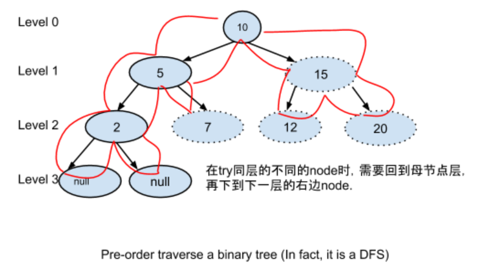

**Recursion v.s. DFS (Search Algorithm)**

- DFS, in more general scope, is one kind of search algorithm.
- DFS can be implemented in an either **recursive way**, or in **iterative way**.

**Back-tracking v.s. DFS**

- Back-tracking describes the behavior of DFS.

# 2 Depth-First Search (DFS)

Recall “using pre-order to traverse a tree”.

實現方法: easy to use **recursion**

常見考題:

- Problem 1: Print all subsets of a set
- Problem 2: Print all valid permutations of () () ()
  - ()()(), ((())), (())()
- Problem 3: 凑硬幣金額 99 cents
  - 1 cent, 5 cents, 10 cents, 25 cents, given 99 cents, print all possible combinations
- Problem 4 (set): (强化練習課)
  1. Given an input string = “127222458”, output all valid ip_address
     - 4 levels
  2. Permutation of a string (with/without duplicate letters)
     - str.length levels
  3. Permutation of all subsequence of a sorted string (allow set to have duplicate elements)
  4. Permutation of factors of a number
     - levels?
  5. How to randomly create a maze? (强化練習課)

**DFS基本方法:**

1. How many levels in the recursion tree? What does it store on each level?
2. How many different states should we try to put on each level?

## 2.1 Problem 1: Print All Subsets

Print all subsets of a set S = {“a”, “b”, “c”}

```
input = a x b x c
        0   0   0
        1   1   1
2 x 2 x 2 = 8
```

```
If S = {"a", "b", "b", "b", "c"}

input = a x b x c
        0   0   0
        1   1   1
            2
            3
```

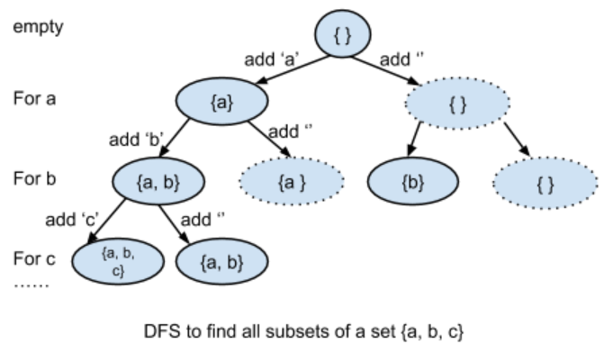

DFS基本方法:

1. How many levels in the recursion tree? What does it store on each level?
   - 3 elements, so 3 levels, and each level represents that one element (add or not add this element in the current level).
2. How many different states should we try to put on each level?
   - Each element can have 2 states (ADD or NOT ADD)

```
char[] input: A B C
int index: 0 (by default)
```

```java
void findSubset(char[] intput, int index, StringBuilder solutionPrefix) { // index: level of recursion
  // Base case: Print solution.
  if (index == input.length) {
    System.out.println(solutionPrefix);
    return;
  }

  // Case 1: Add input[index] to the solution prefix.
  solutionPrefix.append(input[index]);  // Add "A"
  findSubset(input, index + 1, solutionPrefix); // Breaking point...
  solutionPrefix.deleteCharAt(solutionPrefix.length - 1); // Remove "A"

  // Case 2: Do not add input[index] to the solution prefix.
  findSubset(input, index + 1, solutionPrefix);
}
```

- Time: O($2^n$)
- Space: O($\text{height}$) = O($n$)

## 2.2 Problem 2: Find All Valid Permutations of Parentheses

Find all **valid** permutation using the parenthesis provided.

```
e.g.

Given ()()():
Some results:
- ((()))
- ()()()
- (())()
```

Mathematically, whenever we put a right parenthesis there is a left parenthesis to match it.

In more details, whenever we add a “)”, we must guarantee that the number of “(” added so far is larger than the number of “)” added so far.

DFS基本方法:

1. How many levels in the recursion tree? What does it store on each level?
   - 6 levels, each level considers one position (in which there will be only one parenthesis added in this position).
2. How many different states should we try to put on each level?
   - 2 branches, either put “(” OR put “)”

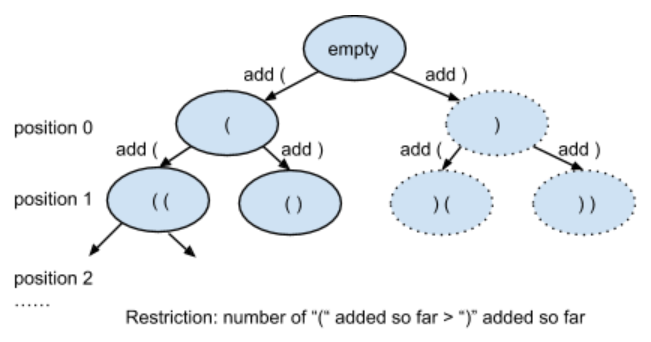

```java
// n stores total number of "pair of ()" need to add. So total levels == 2 * n.
// l stores the number of left parenthesis "(" added so far.
// r stores the number of right parenthesis ")" added so far.
// soluPrefix: solution so far.
void DFS(int n = 3, int l = 0, int r = 0, StringBuilder soluPrefix) {
  // Base case
  if (l == n && r == n) {
    System.out.println(soluPrefix);
    return;
  }

  // Case 1: Add "(" on this level
  if (l < n) {
    soluPrefix.append('(');
    DFS(n, l + 1, r, soluPrefix);
    soluPrefix.deleteCharAt(soluPrefix.length() - 1);
  }

  // Case 2: Add ")" on this level
  if (l > r) {
    soluPrefix.append(')');
    DFS(n, l, r + 1, soluPrefix);
    soluPrefix.deleteCharAt(soluPrefix.length() - 1);
  }
}
```

Because there are $2n$ levels in the recursion tree, and it is a binary tree, therefore there are at most $2^{2n}$ nodes.

- Time: O($2^{2n}$)
- Space: O($2n$)

## 2.3 Problem 3: Print All Combinations of Coins

Print all combinations of coins that can sum up to a total value n.

```
e.g.
coin value = 25, 10, 5, 1

one possible way:
- 25 x 3
- 10 x 2
-  5 x 0
-  1 x 4
```

**Solution 1:**

DFS基本方法:

1. How many levels in the recursion tree? What does it store on each level?
   - 4 levels, each level represents a coin value
2. How many different states should we try to put on each level?
   - Dynamic changing

```
                          99
           /         |          |            \
25:       0          1          2            3
         r=99       r=74       r=49         r=24
       / |||| \     /||\       /||\         /||\
10:   0   ...  9
     r=99 ... r=9


5:   ...


1:   ...
```

Because there are 4 levels, and each level AT MOST 99 branches.

- Time: O($99^4$) = O($n^4$)

**Solution 2:**

DFS基本方法:

1. How many levels in the recursion tree? What does it store on each level?
   - Each level represents we take 1 coin out of the hand, max level is 99
2. How many different states should we try to put on each level?
   - 4 branches: 25, 10, 5, 1

```
                       99
               /              \    \     \
L0:           25              10    5     1
             r=74            r=89  r=94  r=98
      /     |    |     \     /||\  /||\  /||\
L1:  25    10    5     1
    r=49  r=64  r=69  r=73

L2: ...


...


L98 (because we can at most take 99 times from the hand and each time we take 1 cent)
```

- Time: O($4^{99}$)=O($4^n$)

```
          Solution 1    v.s.    Solution 2
Time        99^4       <<<<<      4^99
Space       O(4)                  O(99)

When n = 999999999999
Space       O(4)                O(999999999999)
                                Stack Overflow!
```

```java
void findCombination(int[] coin, int moneyLeft = 99, int index, int[] sol) {
  if (index == 3) {
    sol[index] = moneyLeft;
    System.out.println(sol);
    return;
  }
  // money value on this level == coin[index]
  for (int i = 0; i <= moneyLeft / coin[index]; i++) {
    sol[index] = i;
    findCombination(coin, moneyLeft - i * coin[index], index + 1, sol);
  }
}
```

## 2.4 Problem 4: Print All Permutations of a String

Given a string **with no duplicate letters**, how to print out all permutations of the string.

```
e.g.

input = "ABC"
permutation:
- ABC
- ACB
- BAC
- BCA
- CAB
- CBA
```

```
              root (ABC)
         /         |         \
L0:  A(BC)       B(AC)       C(AB)
     /   \       /   \       /   \
L1: B(C)  C(B)  A(C)  C(A)  A(B)  B(A)
    |     |     |     |     |     |
L2: C     B     C     A     B     A

   ABC   ACB   BAC   BCA   CAB   CBA
```

- Time: O($n!$)

**New Version:**

```
                     root (ABC)
          /              |               \
     swap(A, A)      swap(B, A)      swap(C, A)
L0:    A(*BC)          B(*AC)          C(*BA)
      /      \        /      \        /      \
    B<>B    C<>B    A<>A    C<>A    B<>B    A<>B
L1: B(**C)  C(**B)  A(**C)  C(**A)  A(**B)  B(**A)
    |       |       |       |       |       |
L2: C       B       C       A       B       A

   ABC     ACB     BAC     BCA     CAB     CBA
```

```java
// index is the current layer that we are trying
void permutation(char[] input, int index) {
  // Base case: print solution and return.
  if (index == input.length) {
    System.out.println(input);
    return;
  }

  // Put each letter in the index-th position of the input string.
  for (int i = index; i < input.length; i++) {
    swap(input, index, i);
    permutation(input, index + 1);
    swap(input, index, i);
  }
}
```

- Time: O($n!$)

Conclusion: Whenever every single permutation contains all elements in the initial input, then you should consider SWAP and SWAP.

# 3 Discussion

BFS1 v.s. DFS: Can we use BFS for permutation problems? Why?

- 正確性: OK
- Space: BFS1 can have a very large queue size because the recursion tree can grow exponentially.